# Client Report - What’s in a Name?

- Show All Code
- Hide All Code

Course DS 250

Author

[STUDENT NAME]

```python
import pandas as pd
import numpy as np
from lets_plot import *

LetsPlot.setup_html(isolated_frame=True)
```

## Project Notes

**For Project 1 the answer to each question should include a chart **and** a written response. The years labels on your charts should not include a comma. At least **two** of your charts must include reference marks.**

```python
# Learn morea about Code Cells: https://quarto.org/docs/reference/cells/cells-jupyter.html

# Include and execute your code here
df = pd.read_csv("https://github.com/byuidatascience/data4names/raw/master/data-raw/names_year/names_year.csv")
```

## QUESTION|TASK 1

**How does your name at your birth year compare to its use historically?**

*The name *Thomas* or *Tomas* in 1996 when I was born remained in use but had likely declined from its peak popularity in earlier decades.*

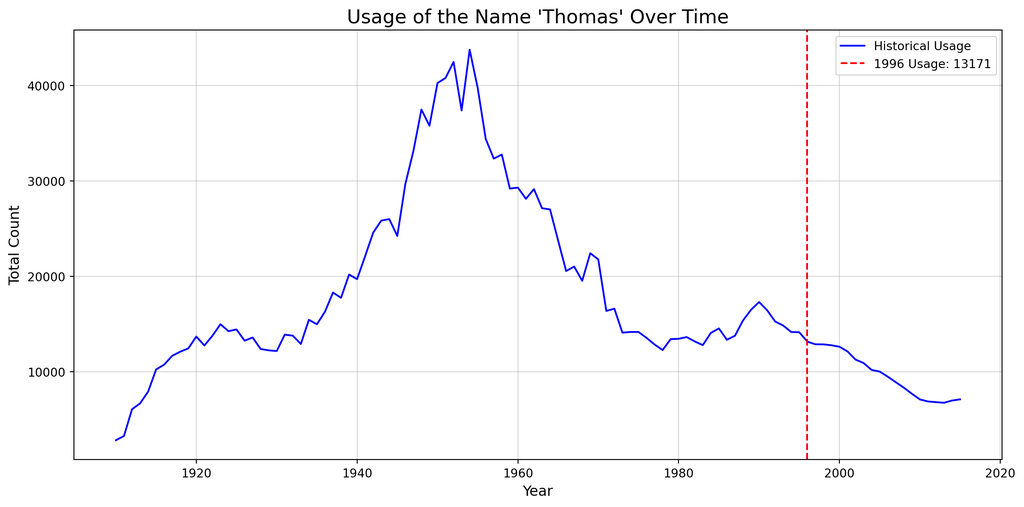

```python
import pandas as pd
import matplotlib.pyplot as plt

# Load the CSV file to check its structure
file_path = 'C:/Users/tomas/OneDrive/BYU- Idaho/DS250-homework/Other files/names_year.csv'
#https://raw.githubusercontent.com/byuidatascience/data4names/master/data-raw/names_year/names_year.csv
data = pd.read_csv(file_path)

# Display the first few rows of the dataset to understand its structure
data.head()
# Filter data for the name 'Thomas'
thomas_data = data[data['name'] == 'Thomas']

# Extract historical data and 1996 usage
thomas_historical = thomas_data.groupby('year')['Total'].sum()
thomas_1996 = thomas_data[thomas_data['year'] == 1996]['Total'].sum()

# Plot the data
plt.figure(figsize=(12, 6))
plt.plot(thomas_historical.index, thomas_historical.values, label='Historical Usage', color='blue')
plt.axvline(x=1996, color='red', linestyle='--', label=f'1996 Usage: {thomas_1996:.0f}')

# Adding labels and title
plt.title("Usage of the Name 'Thomas' Over Time", fontsize=16)
plt.xlabel("Year", fontsize=12)
plt.ylabel("Total Count", fontsize=12)
plt.legend(fontsize=10)
plt.grid(alpha=0.5)

# Show the chart
plt.tight_layout()
plt.show()
```

## QUESTION|TASK 2

**If you talked to someone named Brittany on the phone, what is your guess of his or her age? What ages would you not guess?**

*If I talked with someone named Brittany on the phone, I would guess that they were around 30-40 years old. I would not guess that they were younger or older than that.*

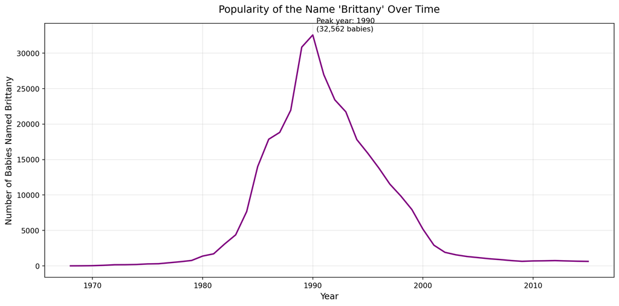

```
Peak popularity year: 1990
```

```python
import pandas as pd
import matplotlib.pyplot as plt

# Load and process the data
#file_path = 'C:/Users/tomas/OneDrive/BYU- Idaho/DS250-homework/Other files/names_year.csv'
data = pd.read_csv('https://raw.githubusercontent.com/byuidatascience/data4names/master/data-raw/names_year/names_year.csv')

# Filter for Brittany and analyze
brittany_data = data[data['name'] == 'Brittany']
brittany_by_year = brittany_data.groupby('year')['Total'].sum()

# Create the visualization
plt.figure(figsize=(12, 6))
plt.plot(brittany_by_year.index, brittany_by_year.values, color='purple', linewidth=2)

# Add labels and styling
plt.title("Popularity of the Name 'Brittany' Over Time", fontsize=14, pad=15)
plt.xlabel("Year", fontsize=12)
plt.ylabel("Number of Babies Named Brittany", fontsize=12)
plt.grid(True, alpha=0.3)

# Find peak year and value
peak_year = brittany_by_year.idxmax()
peak_value = brittany_by_year.max()

# Annotate peak
plt.annotate(f'Peak year: {peak_year}\n({peak_value:,.0f} babies)',
             xy=(peak_year, peak_value),
             xytext=(5, 5),
             textcoords='offset points',
             fontsize=10)

plt.tight_layout()
plt.show()

# Print peak year
print(f"Peak popularity year: {peak_year}")
```

## QUESTION|TASK 3

**Mary, Martha, Peter, and Paul are all Christian names. From 1920 - 2000, compare the name usage of each of the four names in a single chart. What trends do you notice?**

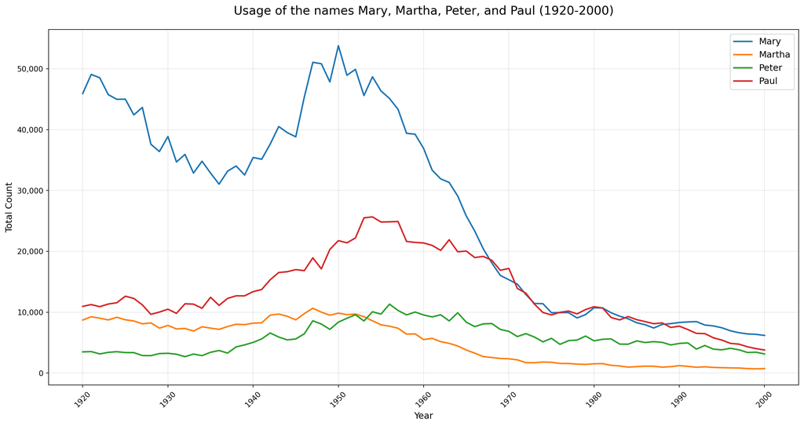

```python
import pandas as pd
import matplotlib.pyplot as plt

# Load the CSV file
file_path = 'C:/Users/tomas/OneDrive/BYU- Idaho/DS250-homework/Other files/names_year.csv'
#https://raw.githubusercontent.com/byuidatascience/data4names/master/data-raw/names_year/names_year.csv
data = pd.read_csv(file_path)

# Create a list of names to analyze
names_to_analyze = ['Mary', 'Martha', 'Peter', 'Paul']

# Create figure with larger size for better readability
plt.figure(figsize=(15, 8))

# Plot each name
for name in names_to_analyze:
    # Filter data for each name
    name_data = data[data['name'] == name]

    # Group by year and sum the total usage
    historical_usage = name_data.groupby('year')['Total'].sum()

    # Filter for years between 1920 and 2000
    historical_usage = historical_usage[(historical_usage.index >= 1920) & (historical_usage.index <= 2000)]

    # Plot the data
    plt.plot(historical_usage.index, historical_usage.values, label=name, linewidth=2)

# Customize the plot
plt.title("Usage of the names Mary, Martha, Peter, and Paul (1920-2000)", fontsize=16, pad=20)
plt.xlabel("Year", fontsize=12)
plt.ylabel("Total Count", fontsize=12)
plt.legend(fontsize=12)
plt.grid(True, alpha=0.3)

# Add thousand separator to y-axis
plt.gca().yaxis.set_major_formatter(plt.FuncFormatter(lambda x, p: format(int(x), ',')))

# Rotate x-axis labels for better readability
plt.xticks(rotation=45)

# Adjust layout to prevent label cutoff
plt.tight_layout()

# Show the plot
plt.show()
```

## QUESTION|TASK 4

**Think of a unique name from a famous movie. Plot the usage of that name and see how changes line up with the movie release. Does it look like the movie had an effect on usage?**

We can see that the name Diego increased in popularity after Argentina won the world cup in 1986 in a very significant way.  
Even peaking in the early 2000s, and then took a hit when Messi took over in popularity.

[figure not shown]

```python
import pandas as pd
import matplotlib.pyplot as plt

# Load the CSV file
file_path = 'C:/Users/tomas/OneDrive/BYU- Idaho/DS250-homework/Other files/names_year.csv'
#https://raw.githubusercontent.com/byuidatascience/data4names/master/data-raw/names_year/names_year.csv
data = pd.read_csv(file_path)

# Filter data for the name 'Harry'
diego_data = data[data['name'] == 'Diego']

# Group by year to calculate the total usage nationwide for each year
diego_historical = diego_data.groupby('year')['Total'].sum()

# Create the plot with a larger size
plt.figure(figsize=(15, 8))

# Plot the data
plt.plot(diego_historical.index, diego_historical.values, label="Diego", color="purple", linewidth=2)

# Add a vertical line for 1986
plt.axvline(x=1986, color='red', linestyle='--', alpha=0.5, label='1986')

# Calculate and show the percent change
if 1986 in diego_historical.index and 1986 in diego_historical.index:
    change_1986_2010 = ((diego_historical[1986] - diego_historical[1986]) / diego_historical[1986] * 100)
    plt.annotate(f'Change 1986-2009: {change_1986_2010:.1f}%',
                xy=(1986, diego_historical[2010]),
                xytext=(10, 30),
                textcoords='offset points',
                bbox=dict(boxstyle='round,pad=0.5', fc='yellow', alpha=0.5))

# Customize the plot
plt.title("Usage of the Name 'Diego' Over Time\nWith 1986 Reference Line\n after Argentina won the world cup", fontsize=16, pad=20)
plt.xlabel("Year", fontsize=12)
plt.ylabel("Total Count", fontsize=12)
plt.legend(fontsize=12)
plt.grid(True, alpha=0.3)

# Add thousand separator to y-axis
plt.gca().yaxis.set_major_formatter(plt.FuncFormatter(lambda x, p: format(int(x), ',')))

# Rotate x-axis labels for better readability
plt.xticks(rotation=45)

# Adjust layout to prevent label cutoff
plt.tight_layout()

# Show the plot
plt.show()
```

## STRETCH QUESTION|TASK 1

**Reproduce the chart Elliot using the data from the `names_year.csv` file.**

```python
# Include and execute your code here
```